# HestonErrorAnalysisFix

### 误差分析

本节比较 Black-Scholes-Merton 模型（BSM，常数波动率）与 Heston 随机波动率模型对同一份 chooser 期权的定价。chooser 为场外产品，基准价格由与普通期权市场价格相一致的 Heston 模型给出：以 2018–2024 年 84 个月度期权链快照（每月首个交易日）逐一校准 Heston 参数，拟合的隐含波动率 RMSE 均值为 1.10 个波动率点；快照之间的交易日沿用最近快照的 $\kappa,\theta,\xi,\rho$，$v_0$ 按 VIX 的变化缩放。样本为 2018-01-02 至 2024-12-31 共 1761 个交易日，每日对两份合约定价：$K=S_t$（固定 moneyness）与 $K=150$，$T_1=0.5$，$T_2=1$。Heston 价格采用 QE 格式的蒙特卡罗（每日 10 万条路径，$[0,T_1]$ 与 $[T_1,T_2]$ 各 32 步），并与特征函数积分得到的半解析解逐日对照。BSM 的波动率取两种设定：$\sigma_{\text{hist}}$ 为 20 日历史波动率，$\sigma_{\text{impl}}$ 为 Heston 在期限 $T_2$、行权价等于远期价格处的隐含波动率。

记 $\tau=T_2-T_1$，$K'=Ke^{-(r-q)\tau}$。在 $r,q$ 为确定性常数的条件下，chooser 的分解公式与模型无关，对任一模型 $M$ 有

$$ V^{M}=C^{M}(K,T_2)+e^{-q\tau}P^{M}(K',T_1). $$

因此 BSM 与 Heston 的价差等于两条腿价差之和：

$$ \Delta V=V^{\text{BSM}}-V^{\text{H}}=\big[C^{\text{BSM}}-C^{\text{H}}\big](K,T_2)+e^{-q\tau}\big[P^{\text{BSM}}-P^{\text{H}}\big](K',T_1). $$

记 $\sigma_C$、$\sigma_P$ 为 Heston 两条腿价格对应的 BSM 隐含波动率，即 $C^{\text{BSM}}(K,T_2;\sigma_C)=C^{\text{H}}(K,T_2)$，$P^{\text{BSM}}(K',T_1;\sigma_P)=P^{\text{H}}(K',T_1)$。由中值定理，

$$ \Delta V=\nu_C\,(\sigma-\sigma_C)+e^{-q\tau}\nu_P\,(\sigma-\sigma_P), $$

其中 $\nu_C,\nu_P$ 为两条腿的 vega，$\sigma$ 为 BSM 采用的常数波动率。两条腿位于波动率曲面的不同位置，Call 腿在 $(K,T_2)$，Put 腿在 $(K',T_1)$，Heston 在两处给出不同的隐含波动率，BSM 对两处使用同一个 $\sigma$，价差由此产生。

对 $\sigma_{\text{hist}}$ 版本，总误差进一步分解为波动率估计误差与曲面形状误差：

$$ V^{\text{BSM}}(\sigma_{\text{hist}})-V^{\text{H}} =\underbrace{V^{\text{BSM}}(\sigma_{\text{hist}})-V^{\text{BSM}}(\sigma_{\text{impl}})}_{\approx\,(\nu_C+e^{-q\tau}\nu_P)(\sigma_{\text{hist}}-\sigma_{\text{impl}})} +\underbrace{V^{\text{BSM}}(\sigma_{\text{impl}})-V^{\text{H}}}_{\text{曲面形状误差}}. $$

第一项反映历史波动率与市场隐含波动率的差异，第二项在两个模型的波动率水平对齐之后保留下来，反映常数波动率假设对偏斜与期限结构的忽略。

误差指标以 $e_t=V^{\text{BSM}}_t-V^{\text{H}}_t$ 为基础（$e_t>0$ 表示 BSM 高估），包括

$$ \text{MAE}=\frac1n\sum_t|e_t|,\quad \text{RMSE}=\sqrt{\frac1n\sum_t e_t^2},\quad \text{Bias}=\frac1n\sum_t e_t,\quad \text{MAPE}=\frac{100}{n}\sum_t\frac{|e_t|}{V^{\text{H}}_t}. $$

每项指标分别在全样本与两个子样本上计算。可靠子样本剔除校准参数触及搜索边界或拟合 RMSE 超过 2 个波动率点的快照（9 个快照，占交易日 10.7%），以及 $v_0$ 触及上界的日期；第二个子样本在此基础上再剔除 120–450 天合约的拟合 RMSE 超过 1.5 个波动率点的快照。

基准价格含三类不确定性：蒙特卡罗的统计误差，由标准误 $\text{se}=s/\sqrt{N}$ 度量；时间离散的系统偏差，由蒙特卡罗与半解析解之差的均值度量；Heston 对市场期权的校准误差，折算为价格约为 $(\nu_C+e^{-q\tau}\nu_P)\times\text{RMSE}_{\text{iv}}$，其中 $\text{RMSE}_{\text{iv}}$ 取两条腿所在期限（120–450 天）的合约。BSM 与 Heston 的价差以这三项为尺度进行解读，超出该尺度的部分归因于模型差异。

### 1 基准的可靠性

```python
import sys
from pathlib import Path

ROOT = next(p for p in [Path.cwd(), *Path.cwd().parents] if (p / "co_bsm").is_dir())
if str(ROOT) not in sys.path:
    sys.path.insert(0, str(ROOT))

import numpy as np
import pandas as pd
import matplotlib.pyplot as plt
from matplotlib import cm
from scipy.stats import norm, rankdata

from co_bsm import calibrate as cal
from co_bsm.black_scholes import BSMParams, bsm_call, bsm_put
from co_bsm.chooser import ChooserParams, chooser_price
from co_bsm.implied_vol import implied_vol
from co_bsm.pricing import HestonPricer
from co_data_center.data_center import DataCenter
from common.paths import get_outputs_path

plt.rcParams["font.sans-serif"] = ["SimHei", "Microsoft YaHei", "PingFang SC",
                                   "Noto Sans CJK SC", "WenQuanYi Zen Hei", "DejaVu Sans"]
plt.rcParams["axes.unicode_minus"] = False
pd.set_option("display.float_format", "{:.4f}".format)
pd.set_option("display.width", 200)

out = get_outputs_path()
prices = pd.read_parquet(out / "chooser_daily_prices.parquet")
params = pd.read_parquet(out / "heston_daily_params.parquet")[["date", "snapshot_date", "rmse_iv_snapshot"]]
feat = DataCenter().get("feature_daily").df
feat = feat.assign(date=pd.to_datetime(feat["date"]))[["date", "vix", "sentiment_score", "news_count"]]

df = prices.merge(params, on="date", how="left").merge(feat, on="date", how="left")
df["reliable"] = ~df["low_conf"] & (df["v0"] < 0.999)      # v0 被截断在上界的日期也算不可靠
BENCH = "heston_mc"

print(f"{df['date'].nunique()} 个交易日，{len(df)} 行；可靠的行占 {df['reliable'].mean():.1%}")
print("MC 列是否完整：", df[BENCH].notna().all())
```

```
2026-10-06 18:31:45 [INFO] co_data_center: feature_daily: 已加载（DataObject，6763 行）
```

```
1761 个交易日，3522 行；可靠的行占 89.3%
MC 列是否完整： True
```

### 1.1 统计误差

```
纯抽样噪声下：z 均值 0，标准差 1，超过 2 的占比 4.6%，超过 3 的占比 0.27%
```

| contract | 天数 | 标准误中位数 | 相对标准误中位数_pct | z均值 | z标准差 | 超过2的占比 | 超过3的占比 |
| --- | --- | --- | --- | --- | --- | --- | --- |
| atm | 1761 | 0.0685 | 0.2914 | -0.0656 | 0.9815 | 0.0460 | 0.0017 |
| k150 | 1761 | 0.0705 | 0.2101 | -0.0541 | 1.0096 | 0.0460 | 0.0034 |

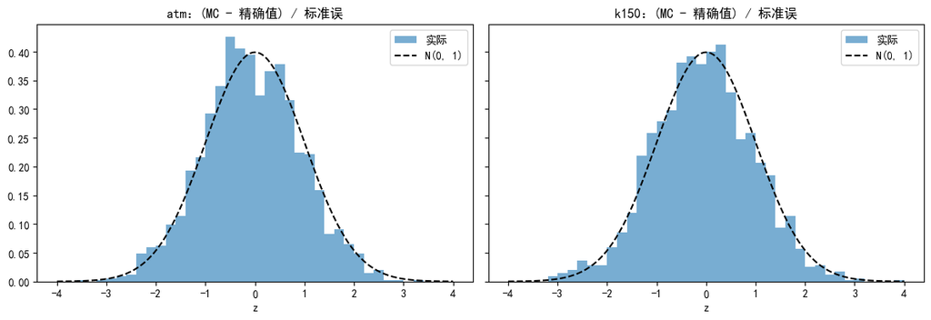

```python
mc = df.dropna(subset=[BENCH, "heston_mc_se"]).copy()
mc["z"] = (mc[BENCH] - mc["heston_exact"]) / mc["heston_mc_se"]
mc["rel_se_pct"] = mc["heston_mc_se"] / mc["heston_exact"] * 100

stat = mc.groupby("contract").agg(
    天数=("z", "size"),
    标准误中位数=("heston_mc_se", "median"),
    相对标准误中位数_pct=("rel_se_pct", "median"),
    z均值=("z", "mean"),
    z标准差=("z", "std"),
    超过2的占比=("z", lambda s: (s.abs() > 2).mean()),
    超过3的占比=("z", lambda s: (s.abs() > 3).mean()),
)
print("纯抽样噪声下：z 均值 0，标准差 1，超过 2 的占比 4.6%，超过 3 的占比 0.27%")
display(stat)

fig, axes = plt.subplots(1, 2, figsize=(12, 4.2), sharey=True)
x = np.linspace(-4, 4, 200)
for ax, (name, g) in zip(axes, mc.groupby("contract")):
    ax.hist(g["z"], bins=40, range=(-4, 4), density=True, alpha=0.6, label="实际")
    ax.plot(x, norm.pdf(x), "k--", label="N(0, 1)")
    ax.set(title=f"{name}：(MC - 精确值) / 标准误", xlabel="z")
    ax.legend()
plt.tight_layout()
plt.show()
```

**统计误差.** 每日 10 万条路径下，蒙特卡罗价格的标准误中位数为 0.069（$K=S_t$）与 0.071（$K=150$），分别占价格的 0.29% 与 0.21%。$z_t=(\hat V_t-V_t^{\text{exact}})/\text{se}_t$ 的标准差为 0.98 与 1.01，绝对值超过 2 的占比均为 4.6%，超过 3 的占比为 0.17% 与 0.34%，与标准正态分布的 4.6% 和 0.27% 吻合，所报告的标准误如实反映了抽样误差。$z_t$ 的均值为 $-0.066$ 与 $-0.054$，对应下一节的平均偏差。

### 1.2 离散误差

```python
mc["bias"] = mc[BENCH] - mc["heston_exact"]
mc["regime"] = np.select([mc["xi"] >= 3.9, mc["kappa"] >= 24.9], ["ξ 撞界", "κ 撞界"], default="其他")


def bias_table(keys):
    rows, index = [], []
    for k, g in mc.groupby(keys):
        n = len(g)
        mean = g["bias"].mean()
        se = np.sqrt((g["heston_mc_se"] ** 2).sum()) / n       # 各天的 MC 相互独立
        rows.append({"天数": n, "平均偏差": mean, "均值标准误": se, "偏差/标准误": mean / se,
                     "平均相对偏差_pct": (g["bias"] / g["heston_exact"]).mean() * 100})
        index.append(k)
    if isinstance(keys, list):
        return pd.DataFrame(rows, index=pd.MultiIndex.from_tuples(index, names=keys))
    return pd.DataFrame(rows, index=pd.Index(index, name=keys))


print("按合约：")
display(bias_table("contract"))
print("按参数状态：")
display(bias_table(["contract", "regime"]))
print("按可靠性：")
display(bias_table(["contract", "reliable"]))
```

```
按合约：
```

| contract | 天数 | 平均偏差 | 均值标准误 | 偏差/标准误 | 平均相对偏差_pct |
| --- | --- | --- | --- | --- | --- |
| atm | 1761 | -0.0052 | 0.0017 | -3.0597 | -0.0181 |
| k150 | 1761 | -0.0030 | 0.0019 | -1.5444 | -0.0111 |

```
按参数状态：
```

| contract | regime | 天数 | 平均偏差 | 均值标准误 | 偏差/标准误 | 平均相对偏差_pct |
| --- | --- | --- | --- | --- | --- | --- |
| atm | κ 撞界 | 19 | -0.0424 | 0.0197 | -2.1481 | -0.1473 |
|  | ξ 撞界 | 147 | -0.0138 | 0.0066 | -2.0982 | -0.0482 |
|  | 其他 | 1595 | -0.0039 | 0.0017 | -2.2456 | -0.0138 |
| k150 | κ 撞界 | 19 | 0.0056 | 0.0277 | 0.2033 | 0.0103 |
|  | ξ 撞界 | 147 | -0.0116 | 0.0071 | -1.6435 | -0.0319 |
|  | 其他 | 1595 | -0.0023 | 0.0020 | -1.1450 | -0.0094 |

```
按可靠性：
```

| contract | reliable | 天数 | 平均偏差 | 均值标准误 | 偏差/标准误 | 平均相对偏差_pct |
| --- | --- | --- | --- | --- | --- | --- |
| atm | False | 188 | -0.0119 | 0.0058 | -2.0404 | -0.0399 |
|  | True | 1573 | -0.0044 | 0.0018 | -2.4821 | -0.0155 |
| k150 | False | 188 | -0.0081 | 0.0065 | -1.2528 | -0.0232 |
|  | True | 1573 | -0.0024 | 0.0020 | -1.1752 | -0.0097 |

**离散误差.** 每日的蒙特卡罗价格与精确值之差取平均后，抽样噪声互相抵消，剩下的是时间离散带来的系统偏差。平均偏差为 $-0.005$（$K=S_t$）与 $-0.003$（$K=150$），分别是均值标准误的 3.1 倍与 1.5 倍，占价格的 0.018% 与 0.011%。参数触及边界的日期偏差更大：$K=S_t$ 合约在 $\kappa$ 触界的 19 天为 $-0.042$（0.15%），在 $\xi$ 触界的 147 天为 $-0.014$；$K=150$ 合约对应为 $+0.006$（不显著）与 $-0.012$。可靠日期的平均偏差为 $-0.004$，不可靠日期为 $-0.012$（$K=S_t$）。步长检验在四组校准得到的真实参数上进行：每日定价采用的每段 32 步下，QE 的偏差在 $-0.04$ 至 $+0.04$ 之间，不超过 1.0 个标准误；Full Truncation 的偏差为 $+0.21$ 至 $+1.06$，为 4.9 至 12.8 个标准误，因此基准采用 QE。

### 1.3 校准误差

```python
PN = ["v0", "kappa", "theta", "xi", "rho"]
hp = pd.read_parquet(out / "heston_params.parquet")
hp = hp[hp["status"] == "ok"].set_index("date")
chain, featc = cal.load_inputs()


def iv_surface(p, ks, Ts):
    """Heston 隐含波动率，只取决于 ln(K/F) 和期限，与 S、r、q 无关。返回 (len(Ts), len(ks))。"""
    S = 100.0
    K = S * np.exp(ks)
    otm = ks >= 0
    res = np.empty((len(Ts), len(ks)))
    for i, T in enumerate(Ts):
        c = HestonPricer(S, 0.0, 0.0, np.full(len(K), T), K).call_prices(**p)
        res[i] = implied_vol(np.where(otm, c, c - (S - K)), S, K, 0.0, T, 0.0, otm)
    return res


def snapshot_options(date):
    S, r, q = cal.market_inputs(featc, date)
    opts, _ = cal.select_options(chain[chain["date"] == date], S, r, q)
    opts["k"] = np.log(opts["K"] / (S * np.exp((r - q) * opts["T"])))
    return opts
```

```
2026-10-06 18:31:45 [INFO] co_data_center: raw_option_chain: 已加载（OptionChainObject，91778 行）
2026-10-06 18:31:45 [INFO] co_data_center: feature_daily: 已加载（DataObject，6763 行）
```

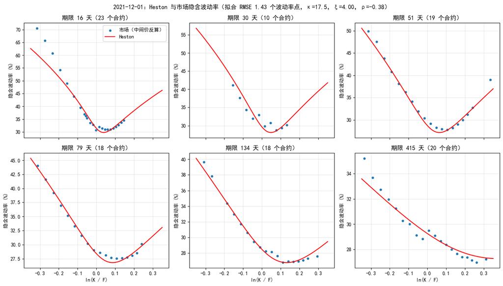

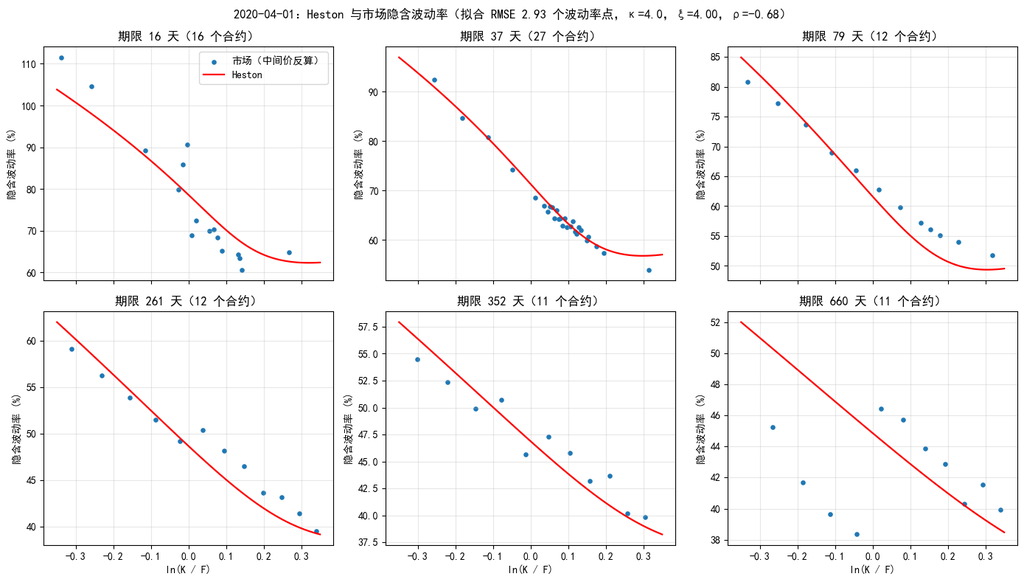

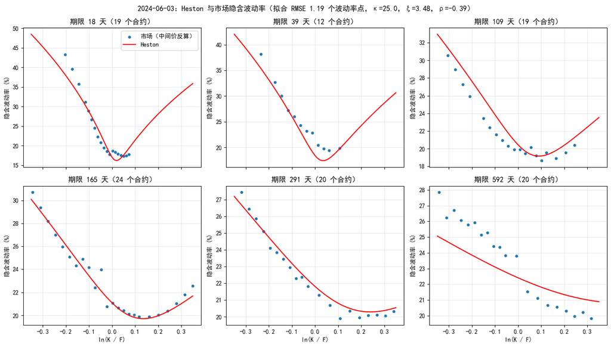

```python
def plot_snapshot(date, n_curves=6):
    date = pd.Timestamp(date)
    row = hp.loc[date]
    p = {k: float(row[k]) for k in PN}
    opts = snapshot_options(date)

    Ts = np.sort(opts["T"].unique())
    pick = Ts[np.unique(np.linspace(0, len(Ts) - 1, n_curves).round().astype(int))]
    ks = np.linspace(-0.35, 0.35, 71)
    fig, axes = plt.subplots(2, 3, figsize=(14, 8), sharex=True)
    for ax, T in zip(axes.flat, pick):
        m = opts[np.isclose(opts["T"], T)]
        ax.scatter(m["k"], m["iv"] * 100, s=14, label="市场（中间价反算）")
        ax.plot(ks, iv_surface(p, ks, np.array([T]))[0] * 100, "r-", lw=1.6, label="Heston")
        ax.set(title=f"期限 {T * 365:.0f} 天（{len(m)} 个合约）", ylabel="隐含波动率 (%)")
        ax.grid(alpha=0.3)
    axes[0, 0].legend()
    for ax in axes[-1]:
        ax.set_xlabel("ln(K / F)")
    fig.suptitle(f"{date.date()}：Heston 与市场隐含波动率（拟合 RMSE {row['rmse_iv']:.2f} 个波动率点，"
                 f"κ={p['kappa']:.1f}，ξ={p['xi']:.2f}，ρ={p['rho']:.2f}）")
    plt.tight_layout()
    plt.show()


for dt in ["2021-12-01", "2020-04-01", "2024-06-03"]:
    plot_snapshot(dt)
```

```python
def fit_errors(date):
    """某个快照上各合约的拟合误差，单位为波动率点（模型 - 市场）"""
    p = {k: float(hp.loc[date, k]) for k in PN}
    opts = snapshot_options(date)
    model = np.empty(len(opts))
    for T in opts["T"].unique():
        m = np.asarray(np.isclose(opts["T"], T))
        model[m] = iv_surface(p, opts.loc[m, "k"].to_numpy(), np.array([T]))[0]
    return pd.DataFrame({"date": date, "days": opts["T"].to_numpy() * 365, "k": opts["k"].to_numpy(),
                         "err": (model - opts["iv"].to_numpy()) * 100})


def rmse(s):
    return np.sqrt((s ** 2).mean())


errs = pd.concat([fit_errors(dt) for dt in hp.index], ignore_index=True)

# 重算的 RMSE 应与校准时记录的一致
snap_rmse = errs.groupby("date")["err"].agg(rmse)
print("与 heston_params 记录的 rmse_iv 的最大差：", float((snap_rmse - hp["rmse_iv"]).abs().max()))

errs["期限"] = pd.cut(errs["days"], [0, 45, 120, 240, 450, 800],
                    labels=["<45 天", "45–120 天", "120–240 天", "240–450 天", ">450 天"])
errs["位置"] = pd.cut(errs["k"], [-1, -0.1, 0.1, 1], labels=["左翼 (k<-0.1)", "平值附近", "右翼 (k>0.1)"])

display(errs.groupby("期限", observed=True)["err"].agg(
    合约数="size", 平均误差="mean", RMSE=rmse, 绝对误差中位数=lambda s: s.abs().median()))
print("平均误差（模型 - 市场，波动率点），按期限和行权价位置：")
display(errs.pivot_table(index="期限", columns="位置", values="err", aggfunc="mean", observed=True))

# 两条腿所在期限（120-450 天）的拟合误差
rel = errs[errs["days"].between(120, 450)].groupby("date")["err"].agg(rmse)
print(f"各快照整体 RMSE 均值 {hp['rmse_iv'].mean():.2f}；120–450 天合约：均值 {rel.mean():.2f}，"
      f"中位数 {rel.median():.2f}，最大 {rel.max():.2f}")

df["rmse_rel"] = df["snapshot_date"].map(rel)
df["fit_ok"] = df["reliable"] & (df["rmse_rel"] <= 1.5)
```

```
与 heston_params 记录的 rmse_iv 的最大差： 2.9909408283401717e-13
```

| 期限 | 合约数 | 平均误差 | RMSE | 绝对误差中位数 |
| --- | --- | --- | --- | --- |
| <45 天 | 8364 | -0.0529 | 1.4053 | 0.8350 |
| 45–120 天 | 2742 | -0.2556 | 1.1649 | 0.7193 |
| 120–240 天 | 3411 | -0.0898 | 0.7974 | 0.4499 |
| 240–450 天 | 3146 | -0.0117 | 0.7534 | 0.4016 |
| >450 天 | 2277 | 0.1032 | 1.1847 | 0.6600 |

```
平均误差（模型 - 市场，波动率点），按期限和行权价位置：
```

| 位置 期限 | 左翼 (k<-0.1) | 平值附近 | 右翼 (k>0.1) |
| --- | --- | --- | --- |
| <45 天 | -0.4952 | 0.0418 | -0.0813 |
| 45–120 天 | -0.1242 | -0.4265 | -0.1725 |
| 120–240 天 | -0.0643 | -0.2399 | 0.0244 |
| 240–450 天 | -0.2658 | -0.0697 | 0.2509 |
| >450 天 | -0.4014 | 0.1242 | 0.5128 |

```
各快照整体 RMSE 均值 1.10；120–450 天合约：均值 0.72，中位数 0.60，最大 2.27
```

```python
# 撞界快照在两条腿所在期限上是否拟合更差
bound = ((hp["kappa"] >= 24.9) | (hp["xi"] >= 3.9)).reindex(rel.index)
display(pd.DataFrame({"撞界": rel[bound].describe(), "未撞界": rel[~bound].describe()}).round(2))

weak = rel[rel > 1.5]
print("120–450 天 RMSE 超过 1.5 的快照：", {str(k.date()): round(v, 2) for k, v in weak.items()})
print("其中已标为低可信度：", [str(k.date()) for k in weak.index if df.loc[df["snapshot_date"] == k, "low_conf"].any()])

# 用 120-450 天的 RMSE 折算校准不确定性，与 BSM 和 Heston 的差距比较
d = df.dropna(subset=["sigma_impl", "rmse_rel"]).copy()


def chooser_at(sig):
    return chooser_price(ChooserParams(S=d["S"].to_numpy(), K=d["K"].to_numpy(), r=d["r"].to_numpy(),
                                       T1=d["T1"].to_numpy(), T2=d["T2"].to_numpy(),
                                       sigma=sig, q=d["q"].to_numpy()))


s = d["sigma_impl"].to_numpy()
d["vega_per_pt"] = chooser_at(s + 0.005) - chooser_at(s - 0.005)      # sigma 变动 1 个点的价格变化
d["calib_unc"] = d["vega_per_pt"] * d["rmse_rel"]
d["gap_impl"] = (d["bsm_impl"] - d[BENCH]).abs()
d["gap_gt_unc"] = d["gap_impl"] > d["calib_unc"]

display(d.groupby("contract").agg(
    相关期限RMSE_点=("rmse_rel", "median"),
    chooser_vega每点=("vega_per_pt", "median"),
    校准不确定性_中位数=("calib_unc", "median"),
    MC标准误_中位数=("heston_mc_se", "median"),
    BSM与Heston绝对差_中位数=("gap_impl", "median"),
    差距大于校准不确定性的占比=("gap_gt_unc", "mean")))
```

|  | 撞界 | 未撞界 |
| --- | --- | --- |
| count | 8.0000 | 76.0000 |
| mean | 0.8400 | 0.7000 |
| std | 0.6000 | 0.3600 |
| min | 0.4300 | 0.2600 |
| 25% | 0.5500 | 0.5100 |
| 50% | 0.6500 | 0.5900 |
| 75% | 0.7700 | 0.7500 |
| max | 2.2700 | 2.0700 |

```
120–450 天 RMSE 超过 1.5 的快照： {'2020-04-01': 2.27, '2020-05-01': 1.87, '2020-06-01': 1.98, '2020-07-01': 1.65, '2020-08-03': 2.07, '2020-09-01': 1.67}
其中已标为低可信度： ['2020-04-01']
```

| contract | 相关期限RMSE_点 | chooser_vega每点 | 校准不确定性_中位数 | MC标准误_中位数 | BSM与Heston绝对差_中位数 | 差距大于校准不确定性的占比 |
| --- | --- | --- | --- | --- | --- | --- |
| atm | 0.6078 | 0.8613 | 0.5823 | 0.0685 | 0.3581 | 0.2993 |
| k150 | 0.6078 | 0.4878 | 0.3891 | 0.0705 | 0.9509 | 0.8132 |

**校准误差.** 84 个快照共 19940 个参与校准的合约，Heston 拟合隐含波动率的 RMSE 为 1.10 个波动率点。按期限分层，RMSE 呈两头高、中间低：期限短于 45 天为 1.41（占合约数的 42%），45–120 天为 1.16，120–240 天为 0.80，240–450 天为 0.75，长于 450 天为 1.18。chooser 的两条腿分别位于约 182 天（$T_1=0.5$）与 365 天（$T_2=1$），落在拟合最好的区间；各快照在 120–450 天合约上的 RMSE 均值为 0.72、中位数为 0.60、最大值为 2.27。拟合误差有系统性的一面：在期限不短于 240 天的合约上，模型相对市场的平均误差在左翼为 $-0.27$ 至 $-0.40$、右翼为 $+0.25$ 至 $+0.51$ 个波动率点，校准得到的偏斜在长期限上比市场平缓。在拟合偏弱的三个快照（2021-12-01、2020-04-01、2024-06-03）上，较大的偏差同样出现在最短与最长的期限：2021-12-01 的 16 天期限上，市场左翼的隐含波动率高于 $\xi$ 触及上界的曲线；2020-04-01 的 16 天期限上，平值附近的市场隐含波动率在 60% 至 91% 之间分散；2024-06-03 的 592 天期限上，市场左翼高于曲线 2–3 个点、右翼低于曲线约 1 个点。

以 120–450 天合约的 RMSE 为准，触及搜索边界的 8 个快照的均值为 0.84（中位数 0.65），其余 76 个为 0.70（0.59），差别不大。该 RMSE 超过 1.5 的快照有 6 个，全部在 2020 年 4 月至 9 月，其中只有 2020-04-01 被标为低可信度。按这一 RMSE 折算，校准不确定性的中位数为 0.58（$K=S_t$）与 0.39（$K=150$），分别是蒙特卡罗标准误的 8.5 倍与 5.5 倍，是基准最主要的不确定性来源。

### 2 BSM 相对基准的表现

```python
def metrics(g, col, bench=BENCH):
    e = g[col] - g[bench]
    pct = e / g[bench] * 100
    return pd.Series({"天数": len(g), "MAE": e.abs().mean(), "RMSE": np.sqrt((e ** 2).mean()),
                      "平均偏差": e.mean(), "偏差中位数": e.median(),
                      "MAPE_pct": pct.abs().mean(), "平均相对偏差_pct": pct.mean(),
                      "P95绝对误差": e.abs().quantile(0.95)})


versions = [("bsm_hist", "σ = 历史波动率"), ("bsm_impl", "σ = Heston 隐含")]
rows = []
for contract, g in df.groupby("contract"):
    subsets = [("全样本", g), ("仅可靠日期", g[g["reliable"]]), ("再剔除相关期限拟合偏弱的快照", g[g["fit_ok"]])]
    for subset, h in subsets:
        for col, label in versions:
            rows.append(metrics(h.dropna(subset=[col, BENCH]), col).rename((contract, subset, label)))
baseline = pd.DataFrame(rows)
baseline.index.names = ["合约", "样本", "BSM 版本"]
display(baseline)
baseline.to_csv(out / "bsm_baseline_metrics.csv", encoding="utf-8-sig")
print("偏差 = BSM - Heston，为正表示 BSM 高估；已保存 bsm_baseline_metrics.csv")

# 基准换成半解析精确值，结果应几乎不变
main = [np.sqrt(((g["bsm_hist"] - g[BENCH]) ** 2).mean()) for _, g in df.groupby("contract")]
alt = [np.sqrt(((g["bsm_hist"] - g["heston_exact"]) ** 2).mean()) for _, g in df.groupby("contract")]
print("RMSE（σ=历史波动率）：以 MC 为基准", np.round(main, 4), "；以精确值为基准", np.round(alt, 4))
```

| 合约 | 样本 | BSM 版本 | 天数 | MAE | RMSE | 平均偏差 | 偏差中位数 | MAPE_pct | 平均相对偏差_pct | P95绝对误差 |
| --- | --- | --- | --- | --- | --- | --- | --- | --- | --- | --- |
| atm | 全样本 | σ = 历史波动率 | 1761.0000 | 6.4372 | 9.4384 | -1.2130 | -3.2835 | 27.2002 | -5.7317 | 14.3883 |
|  |  | σ = Heston 隐含 | 1761.0000 | 0.4112 | 0.5034 | 0.2974 | 0.3109 | 1.8460 | 1.3876 | 0.9673 |
|  | 仅可靠日期 | σ = 历史波动率 | 1573.0000 | 5.7423 | 7.4748 | -2.0731 | -3.3457 | 24.4271 | -9.7885 | 12.7300 |
|  |  | σ = Heston 隐含 | 1573.0000 | 0.3846 | 0.4714 | 0.2756 | 0.2874 | 1.7870 | 1.3565 | 0.9099 |
|  | 再剔除相关期限拟合偏弱的快照 | σ = 历史波动率 | 1467.0000 | 5.6670 | 7.4450 | -2.4072 | -3.4121 | 24.1405 | -11.2262 | 12.3500 |
|  |  | σ = Heston 隐含 | 1467.0000 | 0.3834 | 0.4721 | 0.2691 | 0.2731 | 1.7915 | 1.3396 | 0.9166 |
| k150 | 全样本 | σ = 历史波动率 | 1761.0000 | 4.4029 | 7.3252 | -0.5454 | -0.9384 | 13.0666 | -3.9405 | 11.4492 |
|  |  | σ = Heston 隐含 | 1761.0000 | 1.1160 | 1.3446 | 0.4070 | 0.5303 | 3.2370 | 1.6855 | 2.3690 |
|  | 仅可靠日期 | σ = 历史波动率 | 1573.0000 | 3.6557 | 5.0863 | -1.2365 | -0.8652 | 11.8656 | -5.2311 | 10.5472 |
|  |  | σ = Heston 隐含 | 1573.0000 | 1.1084 | 1.3371 | 0.4018 | 0.5323 | 3.2596 | 1.7364 | 2.3614 |
|  | 再剔除相关期限拟合偏弱的快照 | σ = 历史波动率 | 1467.0000 | 3.6413 | 5.0822 | -1.4904 | -0.9310 | 12.2318 | -5.8990 | 10.5098 |
|  |  | σ = Heston 隐含 | 1467.0000 | 1.1563 | 1.3768 | 0.4114 | 0.5579 | 3.4383 | 1.8271 | 2.3730 |

```
偏差 = BSM - Heston，为正表示 BSM 高估；已保存 bsm_baseline_metrics.csv
RMSE（σ=历史波动率）：以 MC 为基准 [9.4384 7.3252] ；以精确值为基准 [9.4359 7.3251]
```

```python
# BSM 价格是确定的，它与 MC 价格之差的标准误就是 MC 的标准误
rows = []
for contract, g in df.dropna(subset=["bsm_hist", "bsm_impl", BENCH]).groupby("contract"):
    for col, label in versions:
        t = (g[col] - g[BENCH]).abs() / g["heston_mc_se"]
        rows.append({"合约": contract, "BSM 版本": label, "差距/标准误_中位数": t.median(),
                     "差距超过2倍标准误的占比": (t > 2).mean(), "差距超过3倍标准误的占比": (t > 3).mean()})
display(pd.DataFrame(rows).set_index(["合约", "BSM 版本"]))
```

| 合约 | BSM 版本 | 差距/标准误_中位数 | 差距超过2倍标准误的占比 | 差距超过3倍标准误的占比 |
| --- | --- | --- | --- | --- |
| atm | σ = 历史波动率 | 78.0598 | 0.9898 | 0.9864 |
|  | σ = Heston 隐含 | 5.6782 | 0.7978 | 0.7110 |
| k150 | σ = 历史波动率 | 31.9845 | 0.9659 | 0.9415 |
|  | σ = Heston 隐含 | 13.0952 | 0.9364 | 0.9125 |

### 2.1 误差分解

```python
# 总误差 = 波动率估计误差 + 曲面形状误差
# bsm_hist - heston = (bsm_hist - bsm_impl) + (bsm_impl - heston)
rows = []
for contract, g in df.dropna(subset=["bsm_hist", "bsm_impl", BENCH]).groupby("contract"):
    for subset, h in [("全样本", g), ("仅可靠日期", g[g["reliable"]])]:
        parts = {"总误差": h["bsm_hist"] - h[BENCH],
                 "波动率估计误差": h["bsm_hist"] - h["bsm_impl"],
                 "曲面形状误差": h["bsm_impl"] - h[BENCH]}
        for name, e in parts.items():
            rows.append({"合约": contract, "样本": subset, "分量": name,
                         "平均": e.mean(), "RMSE": np.sqrt((e ** 2).mean())})
display(pd.DataFrame(rows).set_index(["合约", "样本", "分量"]))
```

| 合约 | 样本 | 分量 | 平均 | RMSE |
| --- | --- | --- | --- | --- |
| atm | 全样本 | 总误差 | -1.2130 | 9.4384 |
|  |  | 波动率估计误差 | -1.5104 | 9.5415 |
|  |  | 曲面形状误差 | 0.2974 | 0.5034 |
|  | 仅可靠日期 | 总误差 | -2.0731 | 7.4748 |
|  |  | 波动率估计误差 | -2.3487 | 7.5915 |
|  |  | 曲面形状误差 | 0.2756 | 0.4714 |
| k150 | 全样本 | 总误差 | -0.5454 | 7.3252 |
|  |  | 波动率估计误差 | -0.9524 | 7.1149 |
|  |  | 曲面形状误差 | 0.4070 | 1.3446 |
|  | 仅可靠日期 | 总误差 | -1.2365 | 5.0863 |
|  |  | 波动率估计误差 | -1.6382 | 4.9759 |
|  |  | 曲面形状误差 | 0.4018 | 1.3371 |

```python
def bsm_legs(g, sigma):
    """BSM 下 chooser 的两条腿：Call(K, T2) 与 e^{-q tau} Put(K', T1)"""
    S, K, T1, T2 = (g[c].to_numpy() for c in ("S", "K", "T1", "T2"))
    r, q = g["r"].to_numpy(), g["q"].to_numpy()
    tau = T2 - T1
    Kp = K * np.exp(-(r - q) * tau)
    call = bsm_call(BSMParams(S, K, r, T2, sigma, q))
    put = np.exp(-q * tau) * bsm_put(BSMParams(S, Kp, r, T1, sigma, q))
    return call, put


rows = []
for contract, g in df.dropna(subset=["sigma_hist", "sigma_impl"]).groupby("contract"):
    for subset, h in [("全样本", g), ("仅可靠日期", g[g["reliable"]])]:
        for col, label in [("sigma_hist", "σ = 历史波动率"), ("sigma_impl", "σ = Heston 隐含")]:
            sigma = h[col].to_numpy()
            ok = np.isfinite(sigma) & (sigma > 0)
            hh = h[ok]
            call, put = bsm_legs(hh, sigma[ok])
            for leg, bsm_v, hes_v in [("Call 腿", call, hh["heston_call_leg"].to_numpy()),
                                      ("Put 腿", put, hh["heston_put_leg"].to_numpy())]:
                e = bsm_v - hes_v
                rows.append({"合约": contract, "样本": subset, "BSM 版本": label, "腿": leg,
                             "平均偏差": e.mean(), "RMSE": np.sqrt((e ** 2).mean())})
display(pd.DataFrame(rows).set_index(["合约", "样本", "BSM 版本", "腿"]))     # Heston 两条腿取半解析精确值
```

| 合约 | 样本 | BSM 版本 | 腿 | 平均偏差 | RMSE |
| --- | --- | --- | --- | --- | --- |
| atm | 全样本 | σ = 历史波动率 | Call 腿 | -0.9041 | 5.5969 |
|  |  |  | Put 腿 | -0.3141 | 3.8530 |
|  |  | σ = Heston 隐含 | Call 腿 | -0.0069 | 0.1642 |
|  |  |  | Put 腿 | 0.2992 | 0.4461 |
|  | 仅可靠日期 | σ = 历史波动率 | Call 腿 | -1.4081 | 4.4749 |
|  |  |  | Put 腿 | -0.6694 | 3.0138 |
|  |  | σ = Heston 隐含 | Call 腿 | -0.0269 | 0.1560 |
|  |  |  | Put 腿 | 0.2982 | 0.4252 |
| k150 | 全样本 | σ = 历史波动率 | Call 腿 | -0.3771 | 4.6789 |
|  |  |  | Put 腿 | -0.1713 | 2.6726 |
|  |  | σ = Heston 隐含 | Call 腿 | 0.1823 | 0.7830 |
|  |  |  | Put 腿 | 0.2217 | 0.6243 |
|  | 仅可靠日期 | σ = 历史波动率 | Call 腿 | -0.8217 | 3.2443 |
|  |  |  | Put 腿 | -0.4171 | 1.8738 |
|  |  | σ = Heston 隐含 | Call 腿 | 0.1763 | 0.7750 |
|  |  |  | Put 腿 | 0.2230 | 0.6215 |

### 2.2 误差来源

```python
sets = {"各参数的中位数": hp[PN].median().to_dict()}
for dt, label in [("2021-12-01", "ξ 撞界"), ("2024-06-03", "κ 撞界"), ("2020-04-01", "高波动")]:
    sets[f"{dt}（{label}）"] = hp.loc[pd.Timestamp(dt), PN].astype(float).to_dict()

pd.DataFrame(sets).T.round(3)
```

|  | v0 | kappa | theta | xi | rho |
| --- | --- | --- | --- | --- | --- |
| 各参数的中位数 | 0.0540 | 7.5140 | 0.0770 | 1.8550 | -0.5030 |
| 2021-12-01（ξ 撞界） | 0.1410 | 17.5180 | 0.0960 | 4.0000 | -0.3840 |
| 2024-06-03（κ 撞界） | 0.0320 | 25.0000 | 0.0550 | 3.4780 | -0.3890 |
| 2020-04-01（高波动） | 0.7210 | 4.0340 | 0.2800 | 4.0000 | -0.6820 |

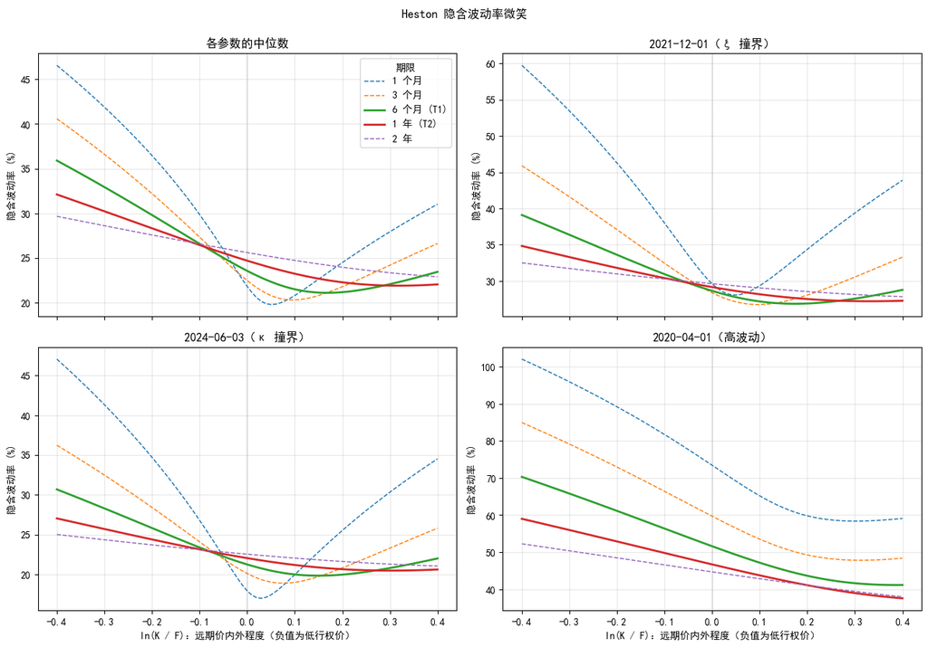

```python
ks = np.linspace(-0.4, 0.4, 81)
maturities = [(1 / 12, "1 个月"), (0.25, "3 个月"), (0.5, "6 个月 (T1)"), (1.0, "1 年 (T2)"), (2.0, "2 年")]

fig, axes = plt.subplots(2, 2, figsize=(13, 9), sharex=True)
for ax, (name, p) in zip(axes.flat, sets.items()):
    surf = iv_surface(p, ks, np.array([t for t, _ in maturities]))
    for row, (t, label) in zip(surf, maturities):
        main_leg = t in (0.5, 1.0)
        ax.plot(ks, row * 100, label=label, lw=2 if main_leg else 1.1, ls="-" if main_leg else "--")
    ax.axvline(0, color="gray", lw=0.6, ls=":")
    ax.set(title=name, ylabel="隐含波动率 (%)")
    ax.grid(alpha=0.3)
axes[0, 0].legend(title="期限")
for ax in axes[1]:
    ax.set_xlabel("ln(K / F)：远期价内外程度（负值为低行权价）")
fig.suptitle("Heston 隐含波动率微笑", y=0.995)
plt.tight_layout()
plt.show()
```

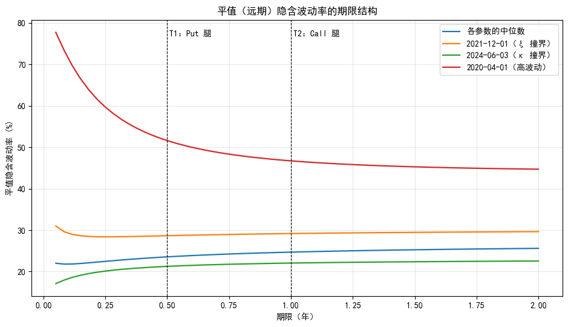

|  | σ(T1=0.5) | σ(T2=1) | P-C（波动率点） |
| --- | --- | --- | --- |
| 各参数的中位数 | 23.5300 | 24.6800 | -1.1400 |
| 2021-12-01（ξ 撞界） | 28.6400 | 29.1600 | -0.5200 |
| 2024-06-03（κ 撞界） | 21.2400 | 22.0400 | -0.8000 |
| 2020-04-01（高波动） | 51.6100 | 46.7100 | 4.8900 |

```python
Ts = np.linspace(0.05, 2.0, 60)
fig, ax = plt.subplots(figsize=(9.5, 5.5))
for name, p in sets.items():
    ax.plot(Ts, iv_surface(p, np.array([0.0]), Ts)[:, 0] * 100, label=name, lw=1.6)
top = ax.get_ylim()[1]
for T, label in [(0.5, "T1：Put 腿"), (1.0, "T2：Call 腿")]:
    ax.axvline(T, color="k", ls="--", lw=0.8)
    ax.text(T + 0.01, top * 0.97, label, va="top")
ax.set(xlabel="期限（年）", ylabel="平值隐含波动率 (%)", title="平值（远期）隐含波动率的期限结构")
ax.legend()
ax.grid(alpha=0.3)
plt.tight_layout()
plt.show()

# 两条腿的远期价内外程度相同，只有期限不同，所以 σ_P - σ_C 就是这条期限结构在 T1 与 T2 之间的落差
tbl = pd.DataFrame({
    name: {"σ(T1=0.5)": iv_surface(p, np.array([0.0]), np.array([0.5]))[0, 0] * 100,
           "σ(T2=1)": iv_surface(p, np.array([0.0]), np.array([1.0]))[0, 0] * 100}
    for name, p in sets.items()}).T
tbl["P-C（波动率点）"] = tbl["σ(T1=0.5)"] - tbl["σ(T2=1)"]
tbl.round(2)
```

```python
# 逐日的两条腿隐含波动率，单位为波动率点
dd = df.dropna(subset=["sigma_impl", "sigma_hist"]).copy()
r, q = dd["r"].to_numpy(), dd["q"].to_numpy()
tau = (dd["T2"] - dd["T1"]).to_numpy()
Kp = dd["K"].to_numpy() * np.exp(-(r - q) * tau)
put_price = dd["heston_put_leg"].to_numpy() / np.exp(-q * tau)      # 还原为 Put(K', T1) 本身

dd["sigma_C"] = implied_vol(dd["heston_call_leg"].to_numpy(), dd["S"].to_numpy(), dd["K"].to_numpy(),
                            r, dd["T2"].to_numpy(), q, True)
dd["sigma_P"] = implied_vol(put_price, dd["S"].to_numpy(), Kp, r, dd["T1"].to_numpy(), q, False)
dd["C-impl"] = (dd["sigma_C"] - dd["sigma_impl"]) * 100
dd["P-C"] = (dd["sigma_P"] - dd["sigma_C"]) * 100
dd["hist-impl"] = (dd["sigma_hist"] - dd["sigma_impl"]) * 100

display(dd.groupby("contract")[["C-impl", "P-C", "hist-impl"]].agg(["mean", "median", "std"]))
print("C-impl：Call 腿位置的隐含波动率减 σ_impl；P-C：Put 腿减 Call 腿；hist-impl：历史波动率减 σ_impl")

atm = dd[dd["contract"] == "atm"].assign(year=lambda x: x["date"].dt.year)
by_year = atm.groupby("year")["P-C"].agg(["mean", "median", "min", "max"])
by_year["P-C>0 的天数占比"] = atm.groupby("year")["P-C"].agg(lambda s: (s > 0).mean())
display(by_year.round(2))
```

| contract | C-impl mean | C-impl median | C-impl std | P-C mean | P-C median | P-C std | hist-impl mean | hist-impl median | hist-impl std |
| --- | --- | --- | --- | --- | --- | --- | --- | --- | --- |
| atm | -0.0238 | -0.0748 | 0.3174 | -0.7738 | -0.9465 | 0.9734 | -1.0225 | -4.2124 | 13.0790 |
| k150 | -0.8754 | -1.4015 | 2.8871 | 0.1108 | -0.4631 | 1.8862 | -1.0225 | -4.2124 | 13.0790 |

```
C-impl：Call 腿位置的隐含波动率减 σ_impl；P-C：Put 腿减 Call 腿；hist-impl：历史波动率减 σ_impl
```

| year | mean | median | min | max | P-C>0 的天数占比 |
| --- | --- | --- | --- | --- | --- |
| 2018 | -0.5500 | -0.7500 | -2.1100 | 5.3500 | 0.1800 |
| 2019 | -1.2800 | -1.2700 | -2.2700 | 0.3300 | 0.0100 |
| 2020 | -0.0500 | -0.6400 | -2.1600 | 5.4200 | 0.2800 |
| 2021 | -1.2600 | -1.3400 | -1.8900 | 0.3200 | 0.0000 |
| 2022 | -0.6700 | -0.8300 | -1.8100 | 2.2900 | 0.1700 |
| 2023 | -1.0600 | -1.1700 | -2.0600 | 0.7200 | 0.0700 |
| 2024 | -0.5400 | -0.6300 | -1.3100 | 1.1800 | 0.1600 |

**曲面与两条腿.** 校准得到的 Heston 隐含波动率曲面具有负偏斜（$\rho$ 在 $-0.69$ 至 $-0.19$），微笑的曲率随期限衰减。chooser 的两条腿位于曲面上同一远期价内外程度，$\ln(K/F(T_2))=\ln(K'/F(T_1))=\ln(K/S)-(r-q)T_2$，只有期限不同，所以两条腿隐含波动率之差只反映该位置的期限结构。在 2021-12-01、2024-06-03 与各参数中位数的快照上，$T_1$ 与 $T_2$ 的平值隐含波动率之差（Put 腿减 Call 腿）为 $-0.52$、$-0.80$ 与 $-1.14$ 个波动率点，期限结构向上；在期限结构倒挂的 2020-04-01 为 $+4.89$。BSM 以单一波动率为两条腿定价，期限结构向上时 Put 腿偏高，倒挂时偏低，这与 $K=S_t$ 合约 Put 腿的平均偏差为正（$+0.30$）的符号相符。

### 3 失效模式

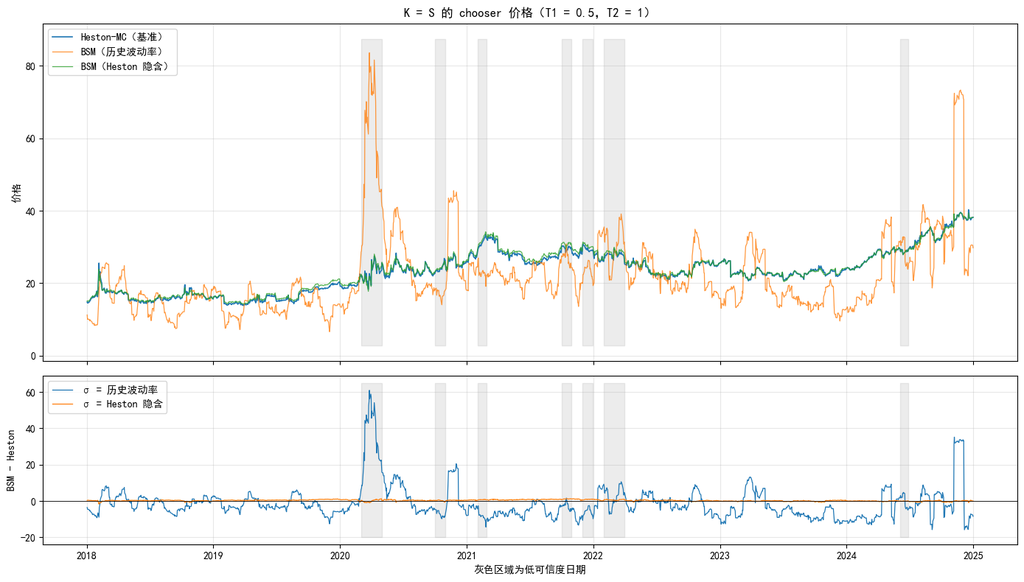

```python
g = df[df["contract"] == "atm"].sort_values("date")
fig, axes = plt.subplots(2, 1, figsize=(14, 8), sharex=True, gridspec_kw={"height_ratios": [2, 1]})

axes[0].plot(g["date"], g[BENCH], label="Heston-MC（基准）", lw=1.2)
axes[0].plot(g["date"], g["bsm_hist"], label="BSM（历史波动率）", lw=0.9, alpha=0.8)
axes[0].plot(g["date"], g["bsm_impl"], label="BSM（Heston 隐含）", lw=0.9, alpha=0.8)
axes[0].set(title="K = S 的 chooser 价格（T1 = 0.5，T2 = 1）", ylabel="价格")
axes[0].legend()

axes[1].plot(g["date"], g["bsm_hist"] - g[BENCH], label="σ = 历史波动率", lw=0.9)
axes[1].plot(g["date"], g["bsm_impl"] - g[BENCH], label="σ = Heston 隐含", lw=0.9)
axes[1].axhline(0, color="k", lw=0.6)
axes[1].set(ylabel="BSM - Heston")
axes[1].legend()

for ax in axes:
    ax.fill_between(g["date"], *ax.get_ylim(), where=~g["reliable"].to_numpy(), color="gray", alpha=0.15, step="mid")
    ax.grid(alpha=0.3)
axes[1].set_xlabel("灰色区域为低可信度日期")
plt.tight_layout()
plt.show()
```

```python
df["vix_bin"] = pd.cut(df["vix"], bins=[0, 15, 20, 30, 1000], labels=["<15", "15–20", "20–30", "≥30"], right=False)


def by_group(keys):
    rows = []
    for k, g in df.dropna(subset=["bsm_hist", "bsm_impl", BENCH]).groupby(keys, observed=True):
        k = k if isinstance(k, tuple) else (k,)
        a, b = metrics(g, "bsm_hist"), metrics(g, "bsm_impl")
        rows.append(dict(zip(["合约"] + (["分组"] if len(k) == 2 else []), k)) |
                    {"天数": a["天数"], "RMSE(hist)": a["RMSE"], "偏差(hist)": a["平均偏差"], "MAPE%(hist)": a["MAPE_pct"],
                     "RMSE(impl)": b["RMSE"], "偏差(impl)": b["平均偏差"], "MAPE%(impl)": b["MAPE_pct"]})
    return pd.DataFrame(rows)


display(by_group(["contract", "vix_bin"]).set_index(["合约", "分组"]))
```

| 合约 | 分组 | 天数 | RMSE(hist) | 偏差(hist) | MAPE%(hist) | RMSE(impl) | 偏差(impl) | MAPE%(impl) |
| --- | --- | --- | --- | --- | --- | --- | --- | --- |
| atm | <15 | 510.0000 | 8.2744 | -3.9068 | 28.2239 | 0.4484 | 0.3080 | 1.9972 |
|  | 15–20 | 572.0000 | 7.0844 | -2.1547 | 22.5356 | 0.5641 | 0.3565 | 1.9662 |
|  | 20–30 | 539.0000 | 6.8133 | -1.1237 | 21.9563 | 0.4808 | 0.2923 | 1.6044 |
|  | ≥30 | 140.0000 | 22.0761 | 12.1041 | 62.7176 | 0.5147 | 0.0372 | 1.7344 |
| k150 | <15 | 510.0000 | 4.0235 | -2.3450 | 9.7650 | 1.4494 | -0.0258 | 3.6707 |
|  | 15–20 | 572.0000 | 5.3122 | -2.1783 | 13.8585 | 1.2059 | 0.1947 | 2.9014 |
|  | 20–30 | 539.0000 | 5.8727 | -0.1076 | 13.1159 | 1.3564 | 0.8425 | 3.2710 |
|  | ≥30 | 140.0000 | 19.1806 | 10.9960 | 21.6683 | 1.4371 | 1.1741 | 2.8981 |

```python
events = {"2020 年 3–4 月（疫情）": ("2020-02-20", "2020-04-30"),
          "2022 年（加息周期）": ("2022-01-01", "2022-12-31"),
          "2023 年 3–4 月（银行业危机）": ("2023-03-01", "2023-04-15")}
df["event"] = "其他"
for name, (start, end) in events.items():
    df.loc[df["date"].between(start, end), "event"] = name

display(by_group(["contract", "event"]).set_index(["合约", "分组"]))
```

| 合约 | 分组 | 天数 | RMSE(hist) | 偏差(hist) | MAPE%(hist) | RMSE(impl) | 偏差(impl) | MAPE%(impl) |
| --- | --- | --- | --- | --- | --- | --- | --- | --- |
| atm | 2020 年 3–4 月（疫情） | 50.0000 | 35.6212 | 30.1042 | 134.0478 | 0.6726 | 0.0778 | 2.6560 |
|  | 2022 年（加息周期） | 251.0000 | 4.8763 | -0.1992 | 15.8742 | 0.4364 | 0.3038 | 1.4364 |
|  | 2023 年 3–4 月（银行业危机） | 32.0000 | 8.8153 | 5.2773 | 36.4404 | 0.1585 | 0.0539 | 0.6379 |
|  | 其他 | 1428.0000 | 7.7141 | -2.6331 | 25.2427 | 0.5125 | 0.3094 | 1.9167 |
| k150 | 2020 年 3–4 月（疫情） | 50.0000 | 31.2647 | 25.9403 | 43.0366 | 1.3960 | 1.2893 | 2.7009 |
|  | 2022 年（加息周期） | 251.0000 | 4.7472 | 1.4491 | 12.3577 | 1.8525 | 1.6782 | 5.3799 |
|  | 2023 年 3–4 月（银行业危机） | 32.0000 | 9.7731 | 6.7697 | 35.1244 | 1.9786 | 1.9502 | 7.6580 |
|  | 其他 | 1428.0000 | 5.0837 | -1.9873 | 11.6475 | 1.2126 | 0.1181 | 2.7801 |

```python
k150 = df[df["contract"] == "k150"].copy()
k150["S/K"] = k150["S"] / k150["K"]
k150["moneyness"] = pd.cut(k150["S/K"], [0, 0.7, 0.9, 1.1, 1.4, 10], right=False,
                           labels=["<0.7", "0.7–0.9", "0.9–1.1", "1.1–1.4", "≥1.4"])
rows = []
for m, g in k150.dropna(subset=["bsm_hist", "bsm_impl", BENCH]).groupby("moneyness", observed=True):
    a, b = metrics(g, "bsm_hist"), metrics(g, "bsm_impl")
    rows.append({"S/K": m, "天数": a["天数"], "RMSE(hist)": a["RMSE"], "偏差(hist)": a["平均偏差"],
                 "MAPE%(hist)": a["MAPE_pct"], "RMSE(impl)": b["RMSE"], "偏差(impl)": b["平均偏差"],
                 "MAPE%(impl)": b["MAPE_pct"]})
display(pd.DataFrame(rows).set_index("S/K"))
```

| S/K | 天数 | RMSE(hist) | 偏差(hist) | MAPE%(hist) | RMSE(impl) | 偏差(impl) | MAPE%(impl) |
| --- | --- | --- | --- | --- | --- | --- | --- |
| <0.7 | 250.0000 | 14.2662 | 5.6785 | 11.1667 | 0.6887 | 0.4665 | 0.9767 |
| 0.7–0.9 | 690.0000 | 4.3378 | 1.2531 | 7.7135 | 1.3732 | 1.1688 | 3.5463 |
| 0.9–1.1 | 510.0000 | 6.8823 | -4.5661 | 23.6186 | 1.1201 | 0.7058 | 3.6168 |
| 1.1–1.4 | 216.0000 | 5.1286 | -4.0551 | 11.8725 | 1.9770 | -1.8996 | 4.4524 |
| ≥1.4 | 95.0000 | 2.8827 | -0.4226 | 3.0138 | 1.7180 | -1.6429 | 2.1371 |

**失效模式.** 历史波动率版本的偏差随市场状态改变符号：$K=S_t$ 合约在 VIX 低于 15 时平均低估 3.91（MAPE 28.2%），在 VIX 不低于 30 时平均高估 12.10（MAPE 62.7%）；2020 年 3–4 月 RMSE 为 35.6、MAPE 为 134%，2023 年 3–4 月 RMSE 为 8.8。历史波动率的价格在 2020 年 3 月（约 83）与 2024 年 11–12 月（约 73）出现尖峰。隐含波动率版本的 RMSE 在各 VIX 分档中保持在 0.45–0.56（$K=S_t$）与 1.21–1.45（$K=150$）；$K=150$ 合约在 2022 年与 2023 年 3–4 月升至 1.85 与 1.98，高于其余时期的 1.21。$K=150$ 合约的形状误差随 $S/K$ 变号：$S/K<1.1$ 时为 $+0.47$ 至 $+1.17$，$S/K\ge1.1$ 时为 $-1.90$ 与 $-1.64$。

### 4 情绪缺口

```python
# 误差与情绪的相关性，只是相关，两个模型都不含情绪
s = df.dropna(subset=["sentiment_score", "vix", "bsm_hist", BENCH]).copy()
s["rel_err"] = (s["bsm_hist"] - s[BENCH]) / s[BENCH] * 100
s["abs_rel_err"] = s["rel_err"].abs()
print(f"有情绪分的交易日占比：{df['sentiment_score'].notna().mean():.1%}")


def rank_corr(x, y):
    return np.corrcoef(rankdata(x), rankdata(y))[0, 1]


def partial_rank_corr(x, y, z):
    """秩的偏相关：把 x、y 的秩对 z 的秩回归，取残差再算相关"""
    rx, ry, rz = rankdata(x), rankdata(y), rankdata(z)
    resid = lambda a: a - np.polyval(np.polyfit(rz, a, 1), rz)
    return np.corrcoef(resid(rx), resid(ry))[0, 1]


rows = []
for contract, g in s.groupby("contract"):
    for target in ["rel_err", "abs_rel_err"]:
        for var in ["sentiment_score", "news_count"]:
            gg = g.dropna(subset=[var])
            rows.append({"合约": contract, "误差": target, "变量": var, "天数": len(gg),
                         "秩相关": rank_corr(gg[var], gg[target]),
                         "控制 VIX 后的偏相关": partial_rank_corr(gg[var], gg[target], gg["vix"])})
display(pd.DataFrame(rows).set_index(["合约", "误差", "变量"]))

s["情绪分组"] = s.groupby("contract")["sentiment_score"].transform(lambda x: pd.qcut(x, 3, labels=["低", "中", "高"]))
display(s.groupby(["contract", "情绪分组"], observed=True)
        .agg(天数=("rel_err", "size"), 平均相对偏差_pct=("rel_err", "mean"), 平均绝对相对偏差_pct=("abs_rel_err", "mean")))
```

```
有情绪分的交易日占比：86.9%
```

| 合约 | 误差 | 变量 | 天数 | 秩相关 | 控制 VIX 后的偏相关 |
| --- | --- | --- | --- | --- | --- |
| atm | rel_err | sentiment_score | 1531 | -0.0263 | -0.0101 |
|  |  | news_count | 1531 | -0.0778 | -0.1348 |
|  | abs_rel_err | sentiment_score | 1531 | -0.0037 | -0.0094 |
|  |  | news_count | 1531 | -0.0237 | -0.0080 |
| k150 | rel_err | sentiment_score | 1531 | -0.0545 | -0.0423 |
|  |  | news_count | 1531 | -0.1872 | -0.2394 |
|  | abs_rel_err | sentiment_score | 1531 | 0.0229 | 0.0296 |
|  |  | news_count | 1531 | 0.1533 | 0.1379 |

| contract | 情绪分组 | 天数 | 平均相对偏差_pct | 平均绝对相对偏差_pct |
| --- | --- | --- | --- | --- |
| atm | 低 | 511 | -3.9551 | 27.6344 |
|  | 中 | 510 | -6.7005 | 26.9727 |
|  | 高 | 510 | -8.5864 | 25.4181 |
| k150 | 低 | 511 | -2.7548 | 13.0831 |
|  | 中 | 510 | -5.1991 | 14.1133 |
|  | 高 | 510 | -5.4768 | 13.4645 |

**情绪缺口.** 在 1531 个有情绪分的交易日上，误差与情绪分的秩相关在 $-0.05$ 到 $+0.02$ 之间；控制 VIX 后，情绪分与有符号误差的偏相关为 $-0.01$（$K=S_t$）与 $-0.04$（$K=150$），情绪分在 VIX 之外对误差没有解释力。与新闻篇数的偏相关分别为 $-0.13$ 与 $-0.24$（有符号误差）、$-0.01$ 与 $+0.14$（绝对误差），幅度较小。按情绪分三等分，$K=S_t$ 的平均相对偏差由 $-4.0\%$ 经 $-6.7\%$ 到 $-8.6\%$，平均绝对相对偏差由 27.6% 降至 25.4%，几乎不随情绪变化。以上均为相关性，两个模型都不含情绪；日度序列自相关强，有效样本远少于 1531 天，未给出显著性检验。

### 5 总结

本节以与市场期权价格一致的 Heston 模型为基准，检验常数波动率的 BSM 对 chooser 期权的定价。基准的蒙特卡罗误差（标准误约 0.07，离散偏差约 0.005）远小于其校准误差（折算为价格约 0.4–0.6），后者决定了差异能否被解读为模型差异。BSM 的表现取决于波动率输入：以历史波动率为输入时 RMSE 为 9.44 与 7.33，偏差随 VIX 变号，2020 年 3–4 月达到 35.6；以 Heston 隐含波动率为输入时降至 0.50 与 1.34。总误差的主要部分来自波动率估计，常数波动率假设带来的曲面形状误差较小：$K=S_t$ 合约的绝对差中位数（0.36）小于折算的校准不确定性（0.58），仅 30% 的交易日超过它，无法与之区分；$K=150$ 合约的（0.95）大于校准不确定性（0.39），81% 的交易日超过它，可以辨别。在控制 VIX 之后，没有发现误差与情绪分的相关。上述比较的是 BSM 与 Heston 的模型差异，不是对市场价格的误差，因为 chooser 没有市场成交价。

### 附录 Heston 隐含波动率曲面

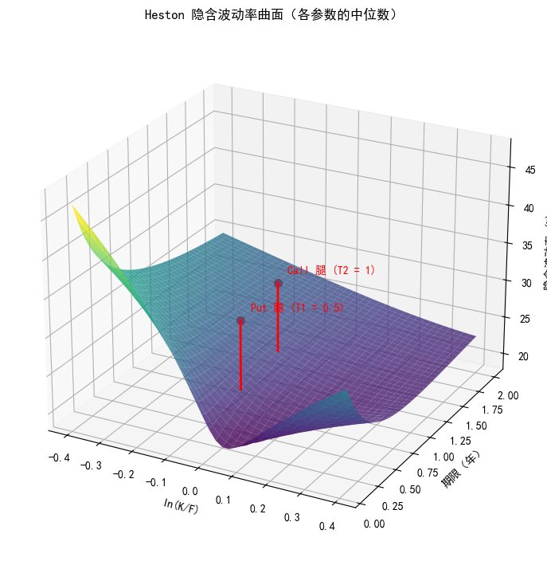

```python
name, p = list(sets.items())[0]
kk = np.linspace(-0.4, 0.4, 41)
TT = np.linspace(0.08, 2.0, 40)
Z = iv_surface(p, kk, TT) * 100
KK, T_ = np.meshgrid(kk, TT)

fig = plt.figure(figsize=(10.5, 7.2))
ax = fig.add_subplot(111, projection="3d")
ax.plot_surface(KK, T_, Z, cmap=cm.viridis, alpha=0.8, linewidth=0, antialiased=True)
for T, label in [(0.5, "Put 腿 (T1 = 0.5)"), (1.0, "Call 腿 (T2 = 1)")]:
    z = iv_surface(p, np.array([0.0]), np.array([T]))[0, 0] * 100
    ax.plot([0, 0], [T, T], [z, z + 9], color="red", lw=2, zorder=10)
    ax.scatter([0], [T], [z + 9], color="red", s=50, depthshade=False, zorder=11)
    ax.text(0.03, T, z + 10.5, label, color="red", zorder=12)
ax.set(xlabel="ln(K/F)", ylabel="期限（年）", zlabel="隐含波动率 (%)", title=f"Heston 隐含波动率曲面（{name}）")
ax.view_init(elev=24, azim=-62)
plt.tight_layout()
plt.show()
```